# Inteligencia Artificial Generativa (AI Gen)

Trabajar con LLMs: prompts, costos y producción

Autor: Paulo Veiga, Claudio Righetti, Marco Sorondo (Universidad Austral)  
Última modificación: 2026-09-02

01Fundamentos 02Modelos y costos 03Prompts estructurados 04In-context learning 05Prompting avanzado 06Effort y thinking 07LLMs en ingeniería 08Resumen y práctica

01

Fundamentos

Fundamentos

## ¿Qué es un prompt?

Un prompt es la instrucción, pregunta o entrada textual que se le da a un modelo de lenguaje grande (LLM) para que genere una respuesta.

### Medio de comunicación

La interfaz principal entre la persona y el modelo.

### Define tarea y contexto

Establece qué hacer y bajo qué condiciones.

### Calidad = resultado

Un prompt mejor produce respuestas más útiles y precisas.

Un prompt se parece a un ticket bien escrito: cuanto más claro el enunciado y las condiciones de aceptación, menos vueltas da quien lo resuelve.

Fundamentos

## ¿Qué se guarda en un prompt?

Todo lo que el modelo ve en un turno vive en la ventana de contexto, y todo compite por su atención al mismo tiempo.

Más contexto no es mejor contexto: el modelo no elige qué leer, procesa todo junto y lo importante se diluye.

[figure not shown]

Fundamentos

## Ventana de contexto

La ventana de contexto es la memoria de trabajo activa del modelo. Contiene todo lo que puede ver en un momento dado para generar la respuesta: system prompt, historial, datos inyectados y sus propias respuestas.

- Es finita. Cuando se llena, el modelo pierde acceso a lo más viejo.
- **Tamaños en 2026**: La carrera por ventanas más largas es la frontera competitiva del momento.

[figure not shown]

Fundamentos

## ¿Cuánto es 1 millón de Tolkien tokens?

"Claude Code tiene ahora una ventana de contexto de 1 millón de tokens por defecto. Un millón de tokens es mucho: la trilogía de El Señor de los Anillos más El Hobbit tienen unas 576.000 palabras, lo que equivale a ~750.000 tokens. Las cuatro obras caben en un único prompt... y aún sobra espacio."

### ~750K tokens

Toda la obra de Tolkien: El Hobbit más la trilogía de El Señor de los Anillos.

### ¿Y un repositorio con código?

El código, los tests y la documentación de un servicio de tamaño medio entran cómodos. La cuenta exacta depende del repo.

[figure not shown]

Fundamentos

## Cómo se tokeniza

**Antes de llegar al modelo, todo texto se parte en piezas de un vocabulario fijo. Ese vocabulario es lo que decide cuántos tokens cuesta una frase, y cada familia de modelos tiene el suyo.**

### BPE — *byte pair encoding*

Arranca de caracteres sueltos y fusiona los pares más frecuentes hasta llenar el vocabulario. Por eso lo común es un token y lo raro se parte en pedazos.

### Vocabulario creciente

De cincuenta mil entradas a doscientas mil. Uno más grande corta menos: el mismo texto rinde menos tokens.

Encoding de `tiktoken` (OpenAI)VocabularioModelos que lo usan

`r50k_base` (gpt2)50.257GPT-2 y los primeros GPT-3

`p50k_base`50.281Codex, text-davinci-002/003

`cl100k_base`100.257GPT-3.5-turbo, GPT-4, embeddings v2/v3

`o200k_base`199.999GPT-4o y la serie o

`o200k_harmony`201.087variante del anterior, formato *harmony*

Fundamentos

## Economía de tokens

Los tokens son subpalabras, no palabras completas. El modelo procesa y factura en tokens, tanto los de entrada como los de salida.

1

"Ingeniería de Software" no cuenta como dos palabras: el tokenizador la parte en varios trozos, y la cuenta exacta cambia según el modelo.

2

Un prompt de 2.000 tokens de entrada más una respuesta de 500 de salida cuesta unos **$0,014** con Claude Sonnet 4.6.

3

[Probarlo en tiempo real: gpt-tokenizer.dev](https://gpt-tokenizer.dev)

Fundamentos

## La fórmula del costo

**Costo total = (tokens de entrada × precio de entrada) + (tokens de salida × precio de salida)**

[figure not shown]

Fundamentos

## Cómo funciona el caching

**El proveedor no guarda respuestas: guarda el estado ya calculado de un prefijo de tokens. De ahí sale la regla única que gobierna todo — coincidencia por prefijo — y también la facilidad con la que se rompe.**

### Coincide por prefijo, no por contenido

No es "¿ya vi este texto antes?". El proveedor guarda el cómputo de los primeros N tokens del pedido; si esos N coinciden byte a byte con los de la llamada anterior, se reutilizan en vez de recalcularse.

### Un byte distinto invalida todo lo que sigue

Y el orden del pedido es fijo: primero las herramientas, después el system prompt, después los mensajes. Por eso lo estable va adelante y lo que cambia en cada llamada va al final.

### Hay un mínimo, y falla en silencio

Un prefijo por debajo del mínimo del modelo no se cachea: sin error, sin aviso. Un prompt corto puede estar marcado para cachear y no cachear nunca.

### Se verifica en la respuesta

El contador de tokens leídos del caché dice si funcionó. Si da cero en llamadas repetidas, hay un invalidador escondido: una fecha en el system prompt, un JSON sin ordenar, una lista de herramientas que cambia de orden.

**Por qué encaja acá**: La bola de nieve de la lámina anterior es un prefijo que crece: cada turno agrega al final y deja intacto lo de antes. El caso ideal para el caching.

Fundamentos

## Del chat al caché programático

**En un chat el prefijo crece solo: cada turno agrega al final y deja intacto todo lo anterior. En una aplicación no hay esa suerte — el pedido lo armás vos, y sos vos quien decide dónde corta la frontera entre lo que se reutiliza y lo que cambia.**

**Monitorear el hit rate**: Si `cache_read_input_tokens` da cero, algo está invalidando el prefijo en silencio.

[figure not shown]

Fundamentos

## Prompt caching: implementación

**El caching se activa marcando las partes estáticas del prompt con un bloque `cache_control`.**

### Parte estática (cacheable)

System prompt, guía de estilo, decisiones de arquitectura, base de conocimiento. Se marca con `cache_control`.

### Parte dinámica (no cacheable)

El diff, el ticket, la consulta puntual. Cambia en cada request, así que va después del corte.

### Hit de caché

Si el prefijo ya fue procesado, el proveedor lo reutiliza en vez de recalcularlo.

Python

```python
import anthropic
client = anthropic.Anthropic()

# ESTATICO -- se cachea (50K tokens)
system_prompt = """Sos un revisor de codigo senior.
Guia de estilo, ADRs y convenciones: [... 50K ...]"""

response = client.messages.create(
    model="claude-sonnet-5",
    system=[{"type": "text", "text": system_prompt,
             "cache_control": {"type": "ephemeral"}}],
    # DINAMICO -- cambia en cada request
    messages=[{"role": "user",
               "content": "Revisa este diff: [... 100 ...]"}])

# Request 1     cache MISS  ->  se procesa y se guarda
# Request 2+    cache HIT   ->  se cobra al 10%
```

Fundamentos

## La economía de los tokens

**La economía del consumo de tokens de IA: cuánto cuesta correr modelos de lenguaje —tokens de entrada contra salida, cacheados contra no cacheados, precio por proveedor— y cómo medir el retorno real que eso genera para el negocio.**

### Lo que ya vimos

Entrada contra salida, la bola de nieve del historial, el prefijo que se cachea y el que no, y el precio distinto de cada proveedor. Todo eso es el lado del costo.

### Lo que falta

La otra mitad de la ecuación: cuánto valor devuelve ese gasto. Es la pregunta que ninguna factura responde.

Fundamentos

## La Tokenomics Foundation

**La Linux Foundation anunció el lanzamiento de la [Tokenomics Foundation](https://www.tokeneconomics.com/), enfocada en establecer estándares abiertos, benchmarks y mejores prácticas para la economía de la infraestructura de IA. Se lanzó el 4 de agosto de 2026 con 30 empresas fundadoras, entre ellas Accenture, IBM, JPMorganChase, Oracle, SAP, ServiceNow, Broadcom y Lenovo.**

### El token es la unidad, no el total

Buena parte del costo no está en los tokens: cómputo, almacenamiento, base de datos, caché y el trabajo de los ingenieros. Pero el token los atraviesa a todos, y por eso sirve para contarlos.

### Falta un lenguaje común

No hay forma compartida de conectar gasto con valor, y cada proveedor cobra distinto. Esa fragmentación vuelve incomparable el costo total entre organizaciones.

### Costo por llamada, no por token

Uno de sus entregables es un método estándar de *costo de servir*: la cuenta completa expresada por llamada, que es la unidad con la que uno diseña un sistema.

### Medición de valor

Un marco que relacione el gasto con resultados, empezando por la proporción de trabajo que se completa sin intervención humana, medida contra lo que ese proceso cuesta hoy.

**Lo más cercano a esta clase**: Su proyecto *Big-T* clasifica la complejidad de costo de una carga de trabajo **antes** de decidir a qué modelo enrutarla: es el árbol de decisión que vimos, convertido en método. Y el número que explica la urgencia: Goldman Sachs proyecta que el consumo de tokens se multiplique por **24 hacia 2030**.

Fundamentos

## Limitaciones de los LLM

### Alucinaciones

El modelo predice texto plausible y no verifica hechos.

Mitigación

Restringirlo al contexto dado más revisión humana.

### No-determinismo

El mismo prompt puede dar respuestas distintas.

En producción

En producción se compensa corriendo varias veces y comparando, no con un parámetro.

### Sesgo de recencia

El modelo presta más atención al principio y al final del prompt que al medio.

Estrategia

Instrucciones críticas al inicio, la consulta concreta al final.

Fundamentos

## ¿Por qué alucina un modelo?

El modelo genera el token más probable dado el contexto. Cuando no tiene el dato, igual genera algo: la fluidez del texto no depende de que sea cierto.

### Sin acceso a hechos verificados

El modelo no consulta una base de verdad. Produce texto plausible a partir de patrones, y plausible no es lo mismo que correcto.

### Entrenamiento incompleto o viejo

Con datos parciales o desactualizados, el modelo extrapola más allá de lo que sabe.

### Confianza sin verificación

No distingue entre lo que sabe y lo que inventa. Responde con la misma seguridad en los dos casos.

### Presión de completado

Siempre intenta terminar el texto, incluso sin información suficiente. Un espacio en blanco no es una salida válida para él.

Fundamentos

## Alucinaciones: casos reales

### Air Canada (2024)

El chatbot inventó una política de tarifas de duelo que no existía. La aerolínea se defendió diciendo que el chatbot era **una entidad legal separada**, responsable de sus propios actos; el tribunal calificó el argumento de notable y lo rechazó: quien despliega el modelo responde por lo que el modelo dice. [Moffatt v. Air Canada, 2024 BCCRT](https://www.canlii.org/en/bc/bccrt/doc/2024/2024bccrt149/2024bccrt149.html)

### Abogados: ya no es anecdótico

Hay **más de 1.148 casos documentados** de alucinaciones en tribunales de EE.UU., y las sanciones escalaron: en el Sexto Circuito, honorarios, costas dobles, **15.000 dólares de sanción punitiva a cada abogado** y derivación disciplinaria. [Norton Rose Fulbright, 2026](https://www.nortonrosefulbright.com/en/knowledge/publications/792d8bf3/ai-in-litigation-update-on-gen-ai-sanctions-in-2026)

### El 19,7% de los paquetes no existe

Sobre 576.000 muestras de código de 16 modelos, **uno de cada cinco paquetes recomendados no existe en ningún registro**: 205.000 nombres únicos inventados. Los modelos abiertos alucinan 21,7% contra 5,2% de los propietarios. [Socket, análisis del paper](https://socket.dev/blog/slopsquatting-how-ai-hallucinations-are-fueling-a-new-class-of-supply-chain-attacks)

### Slopsquatting

El ataque que se monta sobre lo anterior: el atacante **registra el nombre que el modelo alucina** en npm o PyPI y espera. No hay typo humano que explotar; la puerta la abre el asistente de código. El término se acuñó en abril de 2025. Slopsquatting

Fundamentos

## Mitigar alucinaciones: el prompt

Lo que se puede hacer dentro de la llamada al modelo, sin cambiar el sistema alrededor.

### Grounding en contexto

Instruir al modelo a responder solo con el contexto provisto, y a decir que no sabe cuando ese contexto no alcanza.

### RAG (retrieval-augmented generation)

Recuperar e inyectar solo la información verificada y relevante para esa consulta, en vez de confiar en la memoria del modelo.

### Self-consistency

Generar varias respuestas independientes y quedarse con la más frecuente.

### Revisión humana en el loop

El output es siempre un borrador. Alguien del equipo lo valida antes de que llegue a producción.

Fundamentos

## Mitigar alucinaciones: el proceso

El testing formal es la ventaja competitiva de un equipo de software acá: es la disciplina que ya se tiene y que la mayoría de los equipos de producto no aplica a los prompts.

### Dataset de evaluación

Mínimo 50 a 100 casos con ground truth del dominio, anotados por quien sabe.

### Métricas de alucinación

Faithfulness score, hallucination rate, ROUGE-L. Sin métrica no hay umbral de aceptación.

### Regression testing

Correr el eval set completo en cada cambio de prompt, igual que la suite de tests en cada commit.

### Red teaming

Probar con casos ambiguos y contradictorios antes de salir a producción.

**Regla de oro**: Un sistema cuya tasa de alucinación no se puede medir no se despliega.

Fundamentos

## Modelo mental: motores de completado

### Cómo es el modelo

Los LLM completan patrones vistos en el entrenamiento y no entienden la intención.

- **Fortaleza** Muy bueno reconociendo patrones que vio muchas veces.
- **Debilidad** Alucina cuando el patrón no estaba en el entrenamiento.
- **Sin razonamiento interno** Predice el siguiente token más probable, y nada más.

### Qué hacer con eso

Pensarlos como un autocompletado muy sofisticado cambia cómo se escribe el prompt.

- **Prompt vago** "Extraé nombre y email" puede fallar, porque no hay un patrón explícito que completar.
- **Prompt estructurado** Darle el patrón de completado servido: `Nombre: [campo]` / `Email: [campo]` / `De: [texto]`

01Fundamentos 02Modelos y costos 03Prompts estructurados 04In-context learning 05Prompting avanzado 06Effort y thinking 07LLMs en ingeniería 08Resumen y práctica

02

Modelos y costos

Modelos y costos

## Tarifas: familia Claude

ModeloGeneraciónVentanaEntrada ($/MTok)Salida ($/MTok)

Fable 520261M$10,00$50,00

Opus 520261M$5,00$25,00

Opus 4.820261M$5,00$25,00

Sonnet 520261M$2,00$10,00

Sonnet 4.620261M$3,00$15,00

Haiku 4.52025200K$1,00$5,00

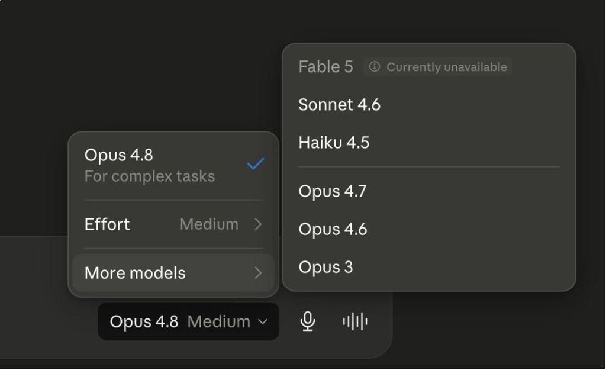

Modelos y costos

## Elegir modelo: la primera pregunta que dé "sí" decide

[figure not shown]

Modelos y costos

## Model cascading

**Intentar primero con el modelo barato. Si la confianza es baja, escalar al caro. El ahorro depende de que el gating de confianza sea confiable.**

[figure not shown]

Modelos y costos

## Cascading: el gate en código

Python

```python
# el gate del cascading es UN CAMPO del esquema de salida:
# structured outputs garantiza que llegue, y con el tipo correcto

from typing import Literal
from anthropic import Anthropic
from pydantic import BaseModel, Field

client = Anthropic()
BARATO, CARO = "claude-haiku-4-5-20251001", "claude-opus-5"

class Triage(BaseModel):
    categoria: Literal["facturacion", "acceso", "bug", "feature"]
    confianza: float = Field(ge=0, le=1, description=(
        "Probabilidad de que un revisor humano experto elija esa "
        "misma categoria. 1,0 el ticket lo dice explicitamente; "
        "0,7 hay senales claras pero falta contexto; 0,4 encaja "
        "en dos categorias; 0,0 no alcanza para decidir."))

PROMPT = ("Clasifica el ticket. No infles la confianza para parecer "
          "util: un 0,4 honesto vale mas que un 0,9 optimista, porque "
          "debajo del umbral el ticket se reenvia a un modelo caro.")

def clasificar(ticket: str) -> tuple[str, str]:
    msg = [{"role": "user", "content": f"{PROMPT}\n\nTicket: {ticket}"}]

    r = client.messages.parse(model=BARATO, max_tokens=256,
                              messages=msg, output_format=Triage)
    if r.parsed_output.confianza >= 0.85:
        return r.parsed_output.categoria, BARATO      # UNA llamada

    # rama larga: la del barato ya se pago igual
    r = client.messages.parse(model=CARO, max_tokens=512,
                              messages=msg, output_format=Triage)
    return r.parsed_output.categoria, CARO            # DOS llamadas
```

Modelos y costos

## Cascading: cuándo sí y cuándo no

### Cuándo conviene

- **Alto volumen de tareas parecidas** Muchas consultas con una distribución de dificultad predecible.
- **Señal de confianza clara** El sistema puede saber cuándo la respuesta barata no alcanza.
- **Presión de costo con piso de calidad** Hay que ahorrar sin bajar la precisión.

### Cuándo evitarlo

- **Latencia baja requerida** Cada escalón agrega una llamada más.
- **Confianza difícil de medir** Sin señal confiable, el routing falla en silencio.
- **Bajo volumen** La complejidad de mantener el routing no se paga.

01Fundamentos 02Modelos y costos 03Prompts estructurados 04In-context learning 05Prompting avanzado 06Effort y thinking 07LLMs en ingeniería 08Resumen y práctica

03

Prompts estructurados

Prompts estructurados

## Los 6 componentes

**La diferencia entre un prototipo que a veces anda y un sistema de producción suele estar en la estructura del prompt, no en la redacción.**

[figure not shown]

Prompts estructurados

## Un prompt completo

**Los seis componentes armados, sobre una tarea real: revisar un pull request.**

Markdown

```markdown
# [1] ROL / PERSONA
Sos un revisor de codigo senior, con experiencia en sistemas de alta disponibilidad.

# [2] CONTEXTO
Estas revisando un pull request sobre el servicio de facturacion.
Las convenciones del equipo estan en CONTRIBUTING.md y en la guia de estilo del lenguaje.

# [3] INSTRUCCIONES
1. Lee el diff completo antes de comentar.
2. Lista los problemas mas graves (maximo 3).
3. Para cada uno, indica archivo y linea.
4. Propone un fix concreto.

# [4] RESTRICCIONES
- No reescribas el modulo entero: solo el fragmento afectado.
- Comenta unicamente lo que aparece en el diff.
- Formato de salida: JSON con las claves severidad, archivo, linea, problema, fix.

# [5] EJEMPLOS (Few-shot)
Diff: se agrega open(path) sin with ni close() en billing/export.py, linea 42.
-> {"severidad": "alta", "archivo": "billing/export.py", "linea": 42,
    "problema": "El descriptor no se cierra si la escritura lanza excepcion.",
    "fix": "Usar with open(path) as f: en lugar de open(path)."}

# [6] INPUT
Diff: en billing/invoice.py, linea 118, se concatena input del usuario
dentro de una query SQL con un f-string.
```

Prompts estructurados

## Salidas estructuradas: JSON Schema

**Imponer un esquema de salida reduce los errores de parseo y los reintentos, y vuelve la salida verificable por código.**

- **Esquema en el prompt**: Incluir el formato JSON en las instrucciones. Más flexible, sin garantías.
- **Modo JSON de la API**: Usar `response_format: json_object`. Más confiable: garantiza estructura válida.

**Validación automática**: La salida se verifica con el esquema, sin leerla a mano.

**Menos errores de parseo**: Menos fallos en el pipeline y menos reintentos.

**Integración directa**: El JSON entra al issue tracker o al bot de review sin traducción intermedia.

[Ver ejemplo interactivo en aitutorial.dev →](https://aitutorial.dev/prompting/structured-prompt-engineering)

JSON

```json
{
  "severidad": "alta | media | baja",
  "archivo": "string",
  "linea": "number",
  "problema": "string",
  "fix": "string"
}
```

Prompts estructurados

## XML: estructura semántica

**Las etiquetas marcan dónde empieza y termina cada parte del prompt. El modelo no tiene que inferir la estructura: se la das dibujada.**

- **Fronteras explícitas**: Tarea, instrucciones, ejemplos y entrada quedan separados sin ambigüedad. Nada se confunde con nada.
- **Formato que ya conocen**: Los LLM se entrenaron con enormes cantidades de HTML y XML de la web, así que la notación les resulta familiar.
- **La salida también se delimita**: Pedir la respuesta dentro de una etiqueta vuelve trivial el parseo y evita que el modelo mezcle explicación con resultado.
- **El overhead se paga solo**: Las etiquetas suman tokens, pero se compensan con menos reintentos y menos errores de parseo. Si el prompt es estable, el caching lo absorbe.

HTML

```xml
<tarea>Clasificar issues de GitHub</tarea>
<instruccion>
Devolve UNA sola palabra: bug, feature o pregunta.
Para cada <entrada>, produci la <salida> correspondiente.
</instruccion>
<ejemplos>
  <ejemplo>
    <entrada>Al exportar a CSV con mas de 10.000 filas, el proceso corta en la 8.192.</entrada>
    <salida>bug</salida>
  </ejemplo>
  <ejemplo>
    <entrada>Estaria bueno poder filtrar el listado por fecha de creacion.</entrada>
    <salida>feature</salida>
  </ejemplo>
  <ejemplo>
    <entrada>¿El endpoint /v2/orders soporta paginacion por cursor?</entrada>
    <salida>pregunta</salida>
  </ejemplo>
</ejemplos>
<entrada>
Despues de actualizar a la 3.2, el login con SSO devuelve 500 en staging.
</entrada>
```

01Fundamentos 02Modelos y costos 03Prompts estructurados 04In-context learning 05Prompting avanzado 06Effort y thinking 07LLMs en ingeniería 08Resumen y práctica

04

In-context learning

In-context learning

## In-context learning (ICL)

**Aprender el patrón desde el prompt, sin tocar los pesos.**

- **El patrón viaja en el pedido**: Los ejemplos van dentro del prompt, no en un entrenamiento previo sobre esa tarea.
- **No se re-entrena**: Los pesos del modelo quedan exactamente iguales antes y después de la llamada.
- **Reconoce y extiende**: Infiere la regla que comparten los ejemplos y la aplica al caso nuevo, en la misma llamada.
- **No persiste**: El aprendizaje muere con la respuesta. El request siguiente vuelve a mandar los ejemplos, y a pagarlos.

[figure not shown]

In-context learning

## Zero-shot vs. few-shot

Python

```python
# ---- ZERO-SHOT ----
# sin ejemplos: el modelo
# elige formato y escala

PROMPT = """
Clasifica la severidad de
este issue.

Issue: el export a CSV
corta en la fila 8.192.
"""

r = client.messages.create(
    model=M, max_tokens=256,
    messages=[
      {"role": "user",
       "content": PROMPT}])

# >>> "Parece un problema de
#      tamano de buffer.
#      Severidad media-alta,
#      segun el uso."
#
# formato libre e
# impredecible: no se
# puede parsear
```

Python

```python
# ---- FEW-SHOT ----
# dos ejemplos antes del
# caso real fijan la escala

PROMPT = """
Clasifica la severidad como
CRITICO, ALTO o BAJO.

Issue: caen los checkouts.
-> CRITICO
Issue: tooltip en ingles.
-> BAJO

Issue: el export a CSV
corta en la fila 8.192.
"""

r = client.messages.create(
    model=M, max_tokens=256,
    messages=[
      {"role": "user",
       "content": PROMPT}])

# >>> "ALTO"
#
# una etiqueta del conjunto
# pedido: el codigo la
# consume directo
```

In-context learning

## Many-shot learning

1

Decenas o cientos de ejemplos, aprovechando las ventanas de contexto grandes.

2

Cuando few-shot no captura la variabilidad del problema.

3

Cuando hay muchas categorías, o categorías con fronteras finas.

4

En producción: agregar ejemplos al prompt a medida que aparecen los errores. Es mejorar el sistema sin re-entrenar nada.

Python

```python
# many-shot: los ejemplos crecen, la llamada no cambia

EJEMPLOS = [
    ("en produccion, todos los checkouts fallan con 500 "
     "desde el deploy de las 14:20.",
     "CRITICO"),   # caida total de una ruta que genera ingresos
    ("el export a CSV corta en la fila 8.192 con datasets grandes.",
     "ALTO"),      # perdida silenciosa de datos, hay workaround
    ("el tooltip del boton Guardar aparece en ingles.",
     "BAJO"),      # cosmetico, no bloquea
    # ... y asi hasta decenas o cientos
]

ISSUE = ("/v2/orders devuelve 200 con body vacio cuando el token "
         "expiro, en lugar de 401. Tres clientes ya cachearon "
         "la respuesta vacia.")

prompt = "Clasifica la severidad del issue como CRITICO, ALTO o BAJO.\n\n"
for texto, etiqueta in EJEMPLOS:
    prompt += f"Issue: {texto}\n-> {etiqueta}\n\n"
prompt += f"Issue: {ISSUE}\n->"

r = client.messages.create(model=M, max_tokens=64,
                           messages=[{"role": "user", "content": prompt}])

# >>> "ALTO"   contrato de API roto: el error se propaga silencioso
#
# cada ejemplo de EJEMPLOS viaja en CADA llamada, y se paga en cada una
```

01Fundamentos 02Modelos y costos 03Prompts estructurados 04In-context learning 05Prompting avanzado 06Effort y thinking 07LLMs en ingeniería 08Resumen y práctica

05

Prompting avanzado

Prompting avanzado

## Cuatro técnicas, una sola idea

**Cuatro técnicas distintas y una sola idea de fondo: todas hacen que el modelo escriba más antes de responder.**

### Chain of Thought (CoT)

Razonamiento paso a paso antes de la respuesta.

### Self-consistency

Varias respuestas independientes y voto por mayoría.

### Tree of Thought (ToT)

Ramas exploradas en paralelo, con poda de las peores.

### Prompt chaining

Una secuencia de prompts simples encadenados.

Prompting avanzado

## Chain of Thought (CoT)

**Mostrarle al modelo el razonamiento paso a paso, no solo el resultado. Es pensar en voz alta.**

### Instrucción directa

Pedirle que razone antes de responder, en el propio prompt.

### Ejemplos con razonamiento explícito

Dar ejemplos donde se ve el proceso de resolución, no solo la respuesta final.

[figure not shown]

Prompting avanzado

## Chain of Thought: ejemplo

**El mismo cálculo con y sin pasos escritos. Las dos respuestas coinciden y solo una se puede auditar.**

- **Sin CoT**: Llega el número y hay que creerle.
- **Con CoT**: Cada paso queda escrito y el error se ve donde ocurre.

En revisión de código y análisis de incidentes, CoT produce un rastro que otra persona puede seguir. Cuesta más latencia, porque la salida es más larga.

[Ejemplo interactivo en aitutorial.dev →](https://aitutorial.dev/prompting/advanced-techniques)

Markdown

```markdown
### Sin CoT
Prompt:    ¿Cuánto es el 15% de propina sobre una cuenta de $47,83?
Respuesta: $7,17

### Con CoT
Prompt:    ¿Cuánto es el 15% de propina sobre una cuenta de $47,83?
           Pensá paso a paso.
Respuesta: 10% de 47,83 = 4,78
           5% es la mitad de eso = 2,39
           15% = 4,78 + 2,39 = 7,17
```

Prompting avanzado

## Self-consistency: votación

### Alto riesgo

Un deploy, una migración de datos, un cambio en facturación.

### Razonamiento complejo

Varias cadenas de pensamiento pueden divergir.

### Clasificación con confianza

Importa cuán seguro está el modelo.

### Validación previa

Medirlo siempre en el eval set propio.

[figure not shown]

Prompting avanzado

## Self-consistency: ejemplo

**Cinco corridas independientes del mismo prompt sobre el mismo diff, y una votación.**

- **Cuándo usarlo**: Cambios donde el error sale caro y el razonamiento admite más de un camino.
- **Costo**: Cinco llamadas al modelo: cinco veces el precio, y la latencia de la más lenta si se lanzan en paralelo.

```
# CASO
Diff en orders/pagination.py

-   return items[offset : offset + limit]
+   return items[offset : offset + limit + 1]

Pregunta: con limit=20, ¿se solapan dos paginas consecutivas?

# CINCO CORRIDAS INDEPENDIENTES DEL MISMO PROMPT

run 1  -> SI   devuelve 21; la pagina 2 arranca en offset=20
run 2  -> SI   el ultimo item se repite al principio de la siguiente
run 3  -> NO   "el slice no cambia el largo"    <- error de razonamiento
run 4  -> SI   21 por pagina, el indice 20 sale dos veces
run 5  -> SI   el +1 pisa el primer item de la pagina siguiente

# VOTACION
-> SI, se solapan        4 de 5 votos        confianza 80%

Ninguna corrida sabe que las otras existen. La equivocada no se
repite; las correctas convergen, y ademas por el mismo motivo.
```

Prompting avanzado

## Tree of Thought (ToT)

**Limitaciones**

**ToT extiende CoT explorando varios caminos de razonamiento en paralelo, como las ramas de un árbol de decisión. El modelo evalúa cada rama y elige la más prometedora.**

### Costo

Cuesta bastante más que un CoT lineal.

### Implementación

Hay que generar ramas, puntuarlas y podar.

### Cuándo rinde

Sirve si el problema admite varias soluciones posibles.

### Cuándo no

En tareas simples el overhead no se justifica.

[figure not shown]

Prompting avanzado

## Tree of Thought: ejemplo

**Razonamiento del modelo**

**Tres estrategias de refactor generadas por el modelo, evaluadas una por una y podadas hasta quedarse con la mejor.**

- **Rama A: módulo de impuestos aparte**: Aísla el cambio y el riesgo queda acotado. **Seleccionada.**
- **Rama B: reescribir el módulo con tests**: Lo más limpio a largo plazo, y sin tests previos no hay red.
- **Rama C: condicionales in situ**: Lo más rápido, y suma complejidad a un módulo que ya no la tolera.

Markdown

```markdown
# CASO
El modulo billing/invoice.py tiene 1.400 lineas, 38 metodos y ningun test.
Hay que agregarle IVA por jurisdiccion sin romper la facturacion actual.

# INSTRUCCION (Tree of Thought)
1. Genera 3 estrategias de refactor posibles
2. Evalua evidencia a favor y en contra de cada una
3. Elegi la mas prometedora y justifica
```

Prompting avanzado

## Prompt chaining

**Dividir una tarea compleja en una secuencia de prompts simples, donde el output de cada paso alimenta al siguiente. Cada paso es más preciso porque se enfoca en una sola sub-tarea.**

**Prompt chaining convierte tareas imposibles en secuencias manejables. Es la base de los agentes de IA modernos.**

[figure not shown]

Prompting avanzado

## Prompt chaining: ejemplo

**Ventajas** y **Trade-offs**

- **Debugging**: Se identifica en qué paso falló, no solo que falló.
- **Resiliencia**: Los pasos que fallan se reintentan por separado.
- **Optimización**: Cada prompt se ajusta a su tarea, y los pasos caros se llaman solo cuando hacen falta.
- **Escalabilidad**: Cada paso se evalúa y se mejora por separado.
- **Más latencia**: Las llamadas son secuenciales.
- El código de orquestación es más complejo.
- Varias llamadas al modelo, aunque el total suele salir más barato.

Markdown

```markdown
# PASO 1 -- Clasificar urgencia
Input:  ticket del usuario
-> Output: ALTA / MEDIA / BAJA

# PASO 2 -- Extraer detalles
Input:  ticket + clasificacion
-> Output: componente afectado, version, pasos para reproducir

# PASO 3 -- Buscar en la base de conocimiento (RAG)
Input:  detalles extraidos
-> Output: incidentes previos parecidos, runbooks aplicables

# PASO 4 -- Generar respuesta
Input:  todo lo anterior
-> Output: respuesta estructurada para el equipo de guardia
```

Prompting avanzado

## Las cuatro técnicas: pros y contras

TécnicaProsContras

**Chain of Thought (CoT)**Razonamiento auditable, mejora la precisión, los errores se detectan.Más latencia y más costo; poco útil en tareas simples; no garantiza corrección.

**Self-consistency**Reduce el error por no-determinismo; da una señal de confianza.Multiplica el costo por 3 a 5 llamadas; más latencia.

**Tree of Thought (ToT)**Explora varios caminos; mejor que CoT en planificación.Muy costoso; complejo de implementar; difícil de controlar.

**Prompt chaining**Pasos simples y reintentables; fácil de evaluar y mejorar.Más latencia total; código de orquestación más complejo.

Prompting avanzado

## ¿Por qué tardan más?

**Más calidad cuesta tiempo de cómputo: más tokens generados, más segundos. No es magia, es aritmética.**

TécnicaEfecto en latencia

**Chain of Thought (CoT)**Genera 100 a 500 tokens de razonamiento antes de la respuesta. Latencia 2 a 5 veces mayor.

**Tree of Thought (ToT)**Proporcional a la cantidad de ramas evaluadas: 3 a 5 veces CoT en los casos habituales.

**Prompt chaining**Cada paso es una llamada independiente. Un pipeline de 5 pasos suma 5 latencias más el procesamiento intermedio.

**Usar estas técnicas solo cuando la precisión justifica el costo. Para tareas simples, un prompt directo es más eficiente.**

Prompting avanzado

## ¿Por qué funcionan?

**El LLM no piensa: predice tokens de izquierda a derecha, y cada uno depende solo de los anteriores. No hay motor de razonamiento oculto, así que lo escrito en la respuesta es el razonamiento.**

### Los tokens intermedios son cálculo

Cada paso escrito condiciona la predicción del siguiente.

### Más contexto, mejor predicción

Un razonamiento de 200 tokens guía mejor que un prompt de 10.

### Se achica el espacio de error

Cada paso recorta la incertidumbre antes de la conclusión.

Es la diferencia entre resolver un problema de cabeza y resolverlo escribiéndolo en papel. El papel no vuelve más inteligente a nadie, y hace la cuenta más precisa.

01Fundamentos 02Modelos y costos 03Prompts estructurados 04In-context learning 05Prompting avanzado 06Effort y thinking 07LLMs en ingeniería 08Resumen y práctica

06

Effort y thinking

Effort y thinking

## Thinking: el mecanismo

**El modelo produce un bloque de razonamiento antes de la respuesta. En los modelos actuales el thinking es adaptativo, así que el modelo evalúa cada petición y decide solo si piensa y cuánto.**

### La decisión es por petición

Una pregunta factual simple vuelve sin bloque; un problema de varios pasos lo dispara.

### El código no puede asumir el bloque

Una misma conversación mezcla turnos con y sin thinking.

### El bloque viaja aparte de la respuesta

Llega con tipo propio, distinto del texto, y `display` decide si vuelve resumido o vacío.

### También piensa entre herramientas

Razona entre llamadas y evalúa cada resultado antes de decidir el paso siguiente.

[figure not shown]

Effort y thinking

## Thinking: cómo queda en código

Python

```python
import anthropic
client = anthropic.Anthropic()

# En Opus 5 y Sonnet 5 el thinking ya viene encendido, con
# display "omitted": el bloque llega vacio salvo que lo pidas.
r = client.messages.create(
    model="claude-opus-5",
    max_tokens=16000,                    # techo de thinking + texto
    thinking={"type": "adaptive",        # el modelo decide si piensa
              "display": "summarized"},  # y si te lo deja ver
    messages=[{"role": "user",
               "content": "¿Este diff introduce un bug?"}])

# La respuesta es una LISTA de bloques, y el de thinking
# puede no estar: en una pregunta simple el modelo no piensa.
razonamiento = texto = firma = None
for b in r.content:
    if b.type == "thinking":
        razonamiento = b.thinking   # "" si display es "omitted"
        firma = b.signature         # se reenvia SIN TOCAR en el turno siguiente
    elif b.type == "text":
        texto = b.text

print(texto)                        # lo unico que ve el usuario
```

Effort y thinking

## Una sola pasada, o una zona de trabajo aparte

**"Un modelo que responde en una sola pasada tiene que acertar todo a la primera: sin borrador, sin verificación, sin poder cambiar de rumbo a mitad de camino."**

Markdown

```markdown
## SIN THINKING
una sola secuencia de tokens

"El" "MCD" "de" "1071" "y"
"462" "es" "21." "Esto" "se"
"calcula" "con" "el"
"algoritmo" "de" "Euclides."
              ^
   token 8: ya se comprometio
   con el numero, sin haber
   hecho la cuenta todavia

> Cada token escrito queda
> fijo: no hay vuelta atras.
> Un error en una resta se
> arrastra hasta el final.
```

Markdown

```markdown
## CON THINKING
dos bloques, uno tras otro

**bloque `thinking`**
zona de trabajo, no es la
respuesta

    "Voy a usar Euclides."
    "1071 = 2 * 462 + 147"
    "462  = 3 * 147 + 21"
    "147  = 7 * 21  + 0"
    "MCD = 21"

**bloque `text`**
recien ahora arranca
lo visible

    "## Encontrando el MCD"
    "Voy a usar el algoritmo
     de Euclides..."

> El numero SALE de la cuenta,
> ya verificado.
```

Effort y thinking

## Qué cambia el bloque separado

**El modelo genera token por token, y cada token nuevo se apoya en todo lo que ya escribió. Si el razonamiento es parte de la respuesta, queda atado a lo que dijo.**

Sin thinkingCon thinking

**Dónde razona**Dentro de la misma respuesta que ves, si es que razona.En un bloque separado, antes de la respuesta.

**Compromiso**Cada token escrito queda fijo. No puede volver atrás y rehacerlo en limpio.Puede desarrollar, probar y corregirse, y recién después condensar.

**Riesgo**Si arranca mal el cálculo tiende a seguir por ese camino: no hay borrador.El error se filtra en el borrador, antes de comprometerse.

**Lo que ves**Todo mezclado, si el modelo decide pensar en voz alta en el texto.Solo la respuesta pulida; el razonamiento queda aparte, visible si lo pedís.

Effort y thinking

## De dónde salió el thinking

**DeepSeek-R1, publicado en Nature en 2025, mostró que el razonamiento se puede incentivar con refuerzo puro: sin trayectorias de razonamiento anotadas por humanos.**

### Nadie le enseñó a razonar

Refuerzo puro, sin una sola trayectoria de razonamiento anotada por humanos. El método saltea el ajuste supervisado previo.

### Solo se premia acertar

La recompensa compara la respuesta final contra la verdadera y no mira el proceso. Por eso tiene que ser verificable a máquina: una caja en matemática, el compilador contra tests en código.

### El razonamiento emergió solo

Autorreflexión, verificación y cambio de estrategia aparecieron sin que nadie los enseñara. Y la respuesta se alargó sola: al modelo le conviene escribir más.

En AIME 2024 el pass@1 promedio va de 15,6% a 77,9%, y llega a 86,7% con self-consistency**, la misma técnica de la sección anterior, usada acá para evaluar.

[figure not shown]

Effort y thinking

## ¿CoT todavía sirve?

**Lo que Chain of Thought conseguía pidiéndolo en el prompt, los modelos de razonamiento lo traen del entrenamiento. El mecanismo es el mismo y cambió quién pide los pasos.**

### El mecanismo no cambió

Wei et al. mostraron que escribir pasos intermedios mejora el desempeño en tareas complejas.

### Antes lo pedía el prompt

"Pensemos paso a paso" producía la cadena; hoy el modelo la produce por su cuenta.

### Ahora lo pide el entrenamiento

El refuerzo con recompensa verificable instala el comportamiento.

### Y también la plataforma

Con el thinking activo, la API incluye un system prompt especializado para soportarlo.

### Por eso algunas técnicas pierden filo

Pedir el paso a paso agrega poco contra un modelo que ya lo hace.

### El costo es invisible

Los tokens de pensamiento se facturan como salida y no vuelven en la respuesta.

**Es la tesis de la clase otra vez: los pasos escritos son el cómputo.** Lo que se movió es la autoría del pedido, del prompt del usuario al entrenamiento del modelo y al system prompt del proveedor.

Effort y thinking

## Effort: un parámetro de la petición

**`effort` es un parámetro de la petición. Gradúa cuántos tokens gasta el modelo al responder e intercambia exhaustividad por eficiencia dentro de un mismo modelo.**

- **`effort` va en `output_config`**: Nunca adentro del objeto `thinking`.
- **`high` es el default**: Pasarlo produce exactamente el mismo comportamiento que omitirlo.

Python

```python
response = client.messages.create(
    model="claude-opus-5",
    max_tokens=16000,
    thinking={"type": "adaptive"},        # el modelo decide si piensa y cuanto
    output_config={"effort": "medium"},   # low | medium | high | xhigh | max
    messages=[{"role": "user", "content": "Clasifica este issue..."}],
)
```

Effort y thinking

## Los cinco niveles de effort

**Cinco niveles, del más rápido al más exhaustivo.**

- **Alcanza a toda la salida**: Texto, llamadas a herramientas y thinking, con el thinking activo o sin él.
- **Con effort bajo el modelo también usa menos herramientas**: Hace menos llamadas y más escuetas.

Es una señal de comportamiento, no un presupuesto de tokens.** Con effort bajo el modelo sigue pensando en los problemas difíciles, y piensa menos que con effort alto para el mismo problema.

NivelComportamiento del thinking

`max`Piensa siempre, sin restricción de profundidad.

`xhigh`Piensa siempre y en profundidad, con exploración extendida.

`high` (default)Piensa casi siempre. Razonamiento profundo en tareas complejas.

`medium`Thinking moderado. Puede saltear el thinking en consultas simples.

`low`Minimiza el thinking. Lo saltea en tareas simples donde manda la velocidad.

Effort y thinking

## Effort por dentro: una señal, no un flag

**`effort` no es una bandera: son tokens que el modelo lee.**

- **Viaja con el prompt**: El valor resuelto se renderiza adentro, al lado de tu pedido.
- **Aprendido, no programado**: El modelo fue entrenado para comportarse distinto en cada nivel, y eso quedó grabado en los pesos congelados.
- **Es señal, no tope**: Con `low` igual piensa en los problemas difíciles: se pesa contra la dificultad real, no la reemplaza.
- **Toca tres cosas a la vez**: Si razona, cuántas herramientas llama y qué tan larga es la respuesta.

Markdown

```markdown
## 1 · Lo que vos escribis

    output_config={"effort": "low"}
    messages=[{"role":"user",
      "content":"¿Cuanto es 12*34?"}]

## 2 · Lo que llega al modelo

    <señal de effort = low>
    ¿Cuanto es 12*34?

> El modelo no recibe una bandera:
> recibe **tokens**. El valor se
> renderiza DENTRO del prompt, al
> lado de tu pedido.
> *(la forma exacta no es publica)*

## 3 · Por que responde distinto

El post-entrenamiento le enseño que
frente a esa señal la respuesta
correcta es **corta y directa**, y que
frente a `max` la respuesta correcta
es **larga y verificada**.

    low  ->  [text] "408"

    max  ->  [thinking]
               "12*30 + 12*4 = 408"
             [text] "408"

> Ese comportamiento esta grabado en
> los **pesos congelados**. No hay
> codigo de servidor que lo implemente:
> es el mismo modelo respondiendo a un
> token distinto en su contexto.
```

Effort y thinking

## Pedirle al modelo que piense

**Que el modelo piense en un turno dado es promptable. El effort fija la postura general y el lenguaje natural corrige el disparo caso por caso.**

### Primero el effort

Fijar el nivel que corresponde al balance de calidad y latencia de la carga de trabajo.

### Después el prompt

Agregar guía en lenguaje natural solo si el disparo del thinking todavía no coincide con lo que hace falta.

### En el system prompt

Cambia el umbral para todas las peticiones de la conversación.

### Por mensaje

Empuja o suprime el thinking en ese turno, sin tocar el system prompt ni cambiar un parámetro.

**Bajar el effort es la primera palanca, porque es un control calibrado.** La guía por prompt depende de las palabras exactas, y empujar al modelo a pensar menos puede bajar la calidad en las tareas que se benefician del razonamiento.

Effort y thinking

## Frases que suben o bajan el thinking

**Las tres redacciones que la documentación da textuales. Están en inglés porque en la práctica los system prompts se escriben en inglés.**

### Para que piense menos, en el system prompt

*"Extended thinking adds latency and should only be used when it will meaningfully improve answer quality, typically for problems that require multistep reasoning. When in doubt, respond directly."*

### Para que piense en este turno

*"Please think hard before responding."*

### Para que responda directo en este turno

*"Answer directly without deliberating."*

**La redacción exacta importa.** Si una frase no produce el comportamiento buscado, la documentación sugiere probar una variante más directa.

01Fundamentos 02Modelos y costos 03Prompts estructurados 04In-context learning 05Prompting avanzado 06Effort y thinking 07LLMs en ingeniería 08Resumen y práctica

07

LLMs en ingeniería

LLMs en ingeniería

## Ciclo de vida: dónde entra el LLM

**El mismo recorrido que hace un cambio desde que alguien lo pide hasta que llega a producción, con lo que un LLM aporta en cada estadio.**

EtapaQué hace hoy

**Issue y triage**Clasifica, deduplica y enruta al equipo correcto.

**Diseño**Redacta ADRs, contrasta alternativas, encuentra precedentes en el propio repo.

**Implementación**Completa código, genera tests, traduce entre lenguajes y frameworks.

**Review**Detecta bugs, marca desvíos de la guía de estilo, resume el diff para el revisor.

**Deploy**Redacta release notes y verifica checklists de salida.

**Incidente**Correlaciona logs, propone hipótesis, redacta el post-mortem.

[figure not shown]

LLMs en ingeniería

## Explorar y entender código

**El otro uso grande no es escribir código: es entender el que ya existe.**

### Búsqueda semántica en repos grandes

Preguntar "dónde se decide si un pedido se factura en dos cuotas" y recibir los tres archivos que importan, en vez de 400 coincidencias de `grep`.

### Comprensión de sistemas legados

Reconstruir el modelo mental de un módulo sin autor vivo: qué hace, qué invariantes asume y qué rompe si se toca.

### Síntesis de documentación

Generar el README que nunca se escribió, a partir del código, los tests y los nombres de las cosas.

### Arqueología de decisiones

Recorrer historial de Git, ADRs y tickets viejos para responder por qué se eligió esto y no aquello.

Las cuatro tareas comparten el mismo riesgo: el modelo produce una explicación coherente aunque el código haga otra cosa. La respuesta se verifica contra el código, siempre.

LLMs en ingeniería

## Casos de uso hoy

**Lo que ya está desplegado en equipos de software, no lo que se promete.**

### Asistentes de código

Completado en el editor y agentes que resuelven un issue completo. Es el uso más adoptado y el más medido.

### Generación de tests

Tests unitarios a partir del código existente, y casos borde que el autor no había pensado.

### Triage automático

Clasificación, deduplicación y ruteo de issues y tickets entrantes.

### Revisión y documentación

Comentarios de review sobre el diff, resúmenes de pull request y documentación generada del código.

Ninguno reemplaza al revisor humano. Los cuatro producen borradores que alguien del equipo aprueba antes de que el cambio entre.

LLMs en ingeniería

## Seguridad: el caso Glasswing

**En abril de 2026 un modelo de frontera sin publicar encontró miles de vulnerabilidades críticas —de forma autónoma, sin dirección humana— en todos los sistemas operativos y navegadores importantes. Doce empresas formaron Project Glasswing para poner esa capacidad del lado de la defensa.**

### OpenBSD: veintisiete años escondida

En uno de los sistemas más endurecidos que existen, el que se usa para correr firewalls e infraestructura crítica. La falla permitía tirar abajo cualquier máquina de forma remota con solo conectarse a ella.

### FFmpeg: el test que no alcanzó

Vulnerabilidad de dieciséis años, en una línea de código que las herramientas de testing automático habían recorrido **cinco millones de veces** sin detectar nunca el problema.

### Linux: encadenar para escalar

El modelo encontró varias vulnerabilidades del kernel y las combinó solo, hasta pasar de usuario común a control total de la máquina.

**Por qué el pipeline se vuelve urgente**: Si un modelo encuentra en semanas lo que sobrevivió décadas de revisión humana y millones de tests, entonces la revisión y los tests que tenés hoy dejaron de ser suficientes. Y la capacidad no es exclusiva de los defensores: el mismo modelo que encuentra la falla para parcharla sabe escribir el exploit.

LLMs en ingeniería

## Oportunidades vs. riesgos

### Oportunidades

- **Bajar el piso de entrada** Tareas que antes exigían un especialista quedan al alcance de más gente del equipo.
- **Liberar tiempo** Menos horas en documentación, boilerplate y tickets repetidos, más horas en diseño.
- **Acelerar la exploración** Evaluar tres alternativas de diseño en el tiempo que antes llevaba evaluar una.
- **Mejorar el onboarding** Alguien que entra puede preguntarle al repositorio en vez de interrumpir a un colega.

### Riesgos

- **Alucinación de APIs y dependencias** Funciones, parámetros y paquetes que no existen, escritos con sintaxis convincente. Una dependencia inventada que alguien registra con ese nombre es un vector de ataque.
- **Código inseguro** El modelo reproduce patrones que vio, y vio mucho código vulnerable: concatenación en SQL, secretos en el repositorio, validación ausente.
- **Dependencia excesiva** Sesgo de automatización: el equipo deja de revisar lo que el modelo produce, y la habilidad de revisar se atrofia.
- **Licencias y procedencia** El código generado puede reproducir fragmentos de código con licencia, y hoy no hay forma simple de rastrear de dónde salió.

LLMs en ingeniería

## Mitigaciones que funcionan

**Ninguna es nueva. Son las prácticas de ingeniería de siempre, aplicadas a un artefacto que casi nadie trata como código.**

### Revisión humana obligatoria

Sin excepción. El output del modelo entra como borrador y una persona lo aprueba. Es la única mitigación que aparece en todas las implementaciones documentadas que funcionan.

### Tests como red

La suite de tests es lo que hace seguro aceptar código que nadie escribió a mano. Sin tests, el código generado es deuda que todavía no se declaró.

### Linters y SAST en el pipeline

El análisis estático agarra la concatenación en SQL y el secreto hardcodeado antes del merge, sin depender de que el revisor esté atento ese día.

### RAG sobre el propio repositorio

Darle al modelo la guía de estilo, los ADRs y el código real del equipo, en vez de confiar en lo que recuerde del entrenamiento.

### Monitoreo continuo

Medir antes y después: tasa de aceptación de sugerencias, defectos que llegan a producción, tiempo de review. Sin medición no hay decisión.

LLMs en ingeniería

## Para pensar

### La evidencia todavía es floja

La mayor parte de lo que se publica sobre productividad con LLMs es observacional o en entornos controlados. Los estudios rigurosos sobre implementaciones reales se cuentan con los dedos.

### La brecha de uso es real

Un modelo capaz usado sin criterio rinde mucho menos que el mismo modelo usado con criterio. El contexto de uso pesa tanto como la tecnología, y esa parte no la resuelve la próxima versión.

### ¿Quién responde cuando falla?

Si el código generado introduce una vulnerabilidad que llega a producción, la responsabilidad no es del modelo. Falta acordar de quién es dentro del equipo, y esa conversación conviene tenerla antes.

### Marco ético de referencia

El deck original apoyaba esta sección en los seis principios de la OMS para grandes modelos multimodales: autonomía, bienestar, transparencia, responsabilidad, equidad y sostenibilidad. Fuera de salud siguen sirviendo como checklist de gobernanza.

LLMs en ingeniería

## Benchmarks: qué miden

**Un benchmark mide una tarea acotada en condiciones de laboratorio. Sirve para comparar modelos entre sí y dice poco sobre cómo va a rendir en el repositorio de cada equipo.**

### Qué mide bien

Capacidad relativa entre modelos sobre una misma tarea cerrada: resolver un problema de programación con tests, responder una pregunta con respuesta única, completar una función.

### Qué no mide

Trabajar sobre una base de código de años, con convenciones propias, deuda técnica y contexto que no está escrito en ninguna parte.

### Contaminación

Un benchmark público lleva años circulando en la web cuando el modelo se entrena. Parte del puntaje puede ser memoria y no capacidad.

### La medición que importa

El eval set propio, con casos reales del dominio. Es la misma conclusión de la sección de testing sistemático.

01Fundamentos 02Modelos y costos 03Prompts estructurados 04In-context learning 05Prompting avanzado 06Effort y thinking 07LLMs en ingeniería 08Resumen y práctica

08

Resumen y práctica

Resumen y práctica

## ¡A practicar!

**Trabajo domiciliario**: Los cuatro módulos son para hacer fuera de clase: 45 a 60 minutos en total. No entran en las dos horas y media de cursada.

#### Foundational Models Fundamentals

aitutorial.dev/prompting/llm-foundamentals — Ventana de contexto, tokens, limitaciones y modelo mental del completado.

#### Técnicas Avanzadas de Prompting

aitutorial.dev/prompting/advanced-techniques — CoT, self-consistency, extended thinking y prompt chaining aplicados.

#### Structured Prompt Engineering

aitutorial.dev/prompting/structured-prompt-engineering — Los 6 componentes, etiquetas XML y salidas JSON en la práctica.

#### Prompt Optimization & Testing

aitutorial.dev/prompting/prompt-optimization-and-testing — Evaluar, iterar y llevar prompts a producción con rigor.

Conclusions

## Key takeaways

### El modelo completa, no razona.

Genera token a token, de izquierda a derecha, sin un motor de razonamiento aparte. Escribir los pasos intermedios es el cómputo, y por eso CoT, self-consistency, ToT y prompt chaining tienen todas la misma forma: hacen que el modelo escriba más antes de responder.

### Cada punto de calidad se paga.

En tokens, en latencia y en dinero. La habilidad central no es conocer las técnicas, es emparejar la técnica y el modelo con la dificultad real de la tarea. Pensar de más en una tarea fácil cuesta plata y a veces empeora la respuesta.

### Un prompt es código.

Se versiona, se testea contra un eval set y se mide antes y después de cada cambio. Sin medición, cualquier mejora es una opinión, y eso vale igual para un chatbot que para un asistente de revisión de código.

Girá el teléfono para ver las diapositivas